# California STAR Test Basic Group Analysis

This notebook presents basic analysis of the California STAR test data files, using the 2012 research file. Each figure below shows the density curves for a subgroup for each of a set of tests and grades, all taken from the 2012 STAR test score research files from the California Department of Education.

The grades are:

- 5
- 8
- 10

The tests, and their codes, are:

- 7: CST English-Language Arts
- 9: CST Algebra I
- 32: CST Science - Grade 5, Grade 8, and Grade 10 Life Science

See [The STAR website](http://star.cde.ca.gov/star2012/research_fixfileformat.aspx) for a description of all of the field codes.

## What's a Density Curve?

A Density curve is a lot like a histogram, but instead of showing you the number of students with scores in each band, it shows you the probability of finding a student with a particular score. However, for most use, and for visual analysis, the density curves can be used like histograms. They have approximately the same shape, but are smoother.

The curves are generated with a Gaussian KDE using Scotts rule for bandwidth estimation. The data points are drawn from all schools in California.

## Notes

There are a few interesting features in these curves:

- For Grade 8, Test 32 (Science), the curves appear wider that for Grade 5 and Grade 10
- Grade 8 also appers wider for Test 9, Algebra.

```python
%matplotlib inline
import ambry
import pandas as pd
import numpy as np
import matplotlib.pyplot as plt

l = ambry.ilibrary()
p = l.get('cde.ca.gov-star-orig-star-2012').partition
```

```python
def plot_groups(df, ax, subgroups, test_id, grade, title):
    from scipy.stats import gaussian_kde

    ax.grid(color='w', linewidth=2, linestyle='solid')

    colors = 'k','r','b','g','m','c'

    for i, subgroup in enumerate(subgroups):
        data = df[(df['subgroup'] == subgroup) &
                  (df['test_id'] == int(test_id)) &
                  (df['grade'] == grade)].mean_score.dropna()

        ax.set_title(title)

        if len(data.index) < 2:
            continue

        #print subgroup, test_id, grade, len(data)

        density = gaussian_kde(data,'scott')
        xs = np.linspace(0,data.max(),200)
        ax.plot(xs,density(xs), color=colors[i], label=str(subgroup))
        ax.set_xlim(200, 600)
        ax.set_ylim(0,0.025)

def get_data(subgroups):
    df = p.select("""
    SELECT subgroup, grade, test_id, mean_score from star
    WHERE subgroup IN ({subgroups}) AND school != 0"""
                  .format(subgroups=','.join([str(x) for x in subgroups]))).pandas

    return df

def plot_groups_grid(df, subgroups, grades, tests):

    fig, axes = plt.subplots(nrows = len(grades), ncols=len(tests),
                         #sharex='col',
                         sharey='row', figsize=(15, 15),
                         subplot_kw={'axisbg':'#EEEEEE', 'axisbelow':True})


    for col, test_id in enumerate(tests):
        for row, grade in enumerate(grades):
            plot_groups(df, axes[row][col], subgroups, test_id, grade, 'test={} grade={}'.format( test_id, grade))

    plt.legend( ncol = len(subgroups), mode="expand", loc = 'lower center', bbox_to_anchor = (0,.05,1,1),
                bbox_transform = plt.gcf().transFigure, borderaxespad=0., prop={'size':18} )
```

## Parent Education

Density curves by parental education:

- 90 (Black) Not a High School Graduate
- 91 (Red) High School Graduate
- 92 (Blue) Some College (Includes AA Degree)
- 93 (Green) College Graduate
- 94 (Magenta) Graduate School/Postgraduate Training
- None Parent Education -- Declined to State

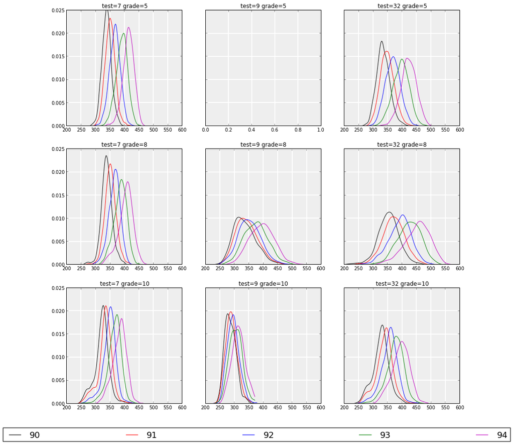

```python
subgroups = [90,91,92,93,94]
df = get_data(subgroups)
tests = [7,9,32]
grades = [5,8,10]

plot_groups_grid(df, subgroups, grades, tests)
```

### Counts

Counts by subgroup, test_id and grade.

```python
print df.groupby('subgroup').count()['subgroup']
```

```
subgroup
90          175569
91          196085
92          191521
93          169348
94          136527
Name: subgroup, dtype: int64
```

```python
df[(df.test_id.isin(tests)) & (df.grade.isin(grades))].groupby(['test_id', 'grade']).count()['test_id']
```

```
test_id  grade
7        5        26185
         8        12292
         10       10377
9        8        10527
         10        7717
32       5        26191
         8        12267
         10       10116
Name: test_id, dtype: int64
```

## Racial Group

By racial group, not economically disadvantaged

- 220 (Black) Black or African American
- 224 (Red) Hispanic or Latino
- 226 (Blue) White
- 222 (Green) Asian

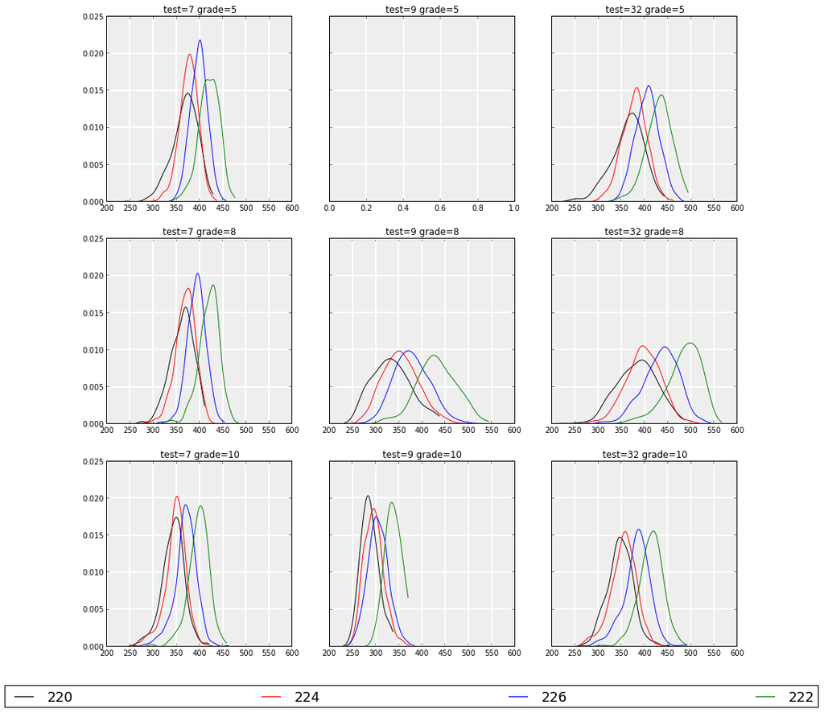

```python
# Non ED AA, Hisp, white, Asian

subgroups = [220,224,226,222]
df = get_data(subgroups)
plot_groups_grid(df, subgroups, grades, tests)
```

### Counts

```python
print df.groupby('subgroup').count()['subgroup']
print "\n\n"
print df[(df.test_id.isin(tests)) & (df.grade.isin(grades))].groupby(['test_id', 'grade']).count()['test_id']
```

```
subgroup
220          78583
222          76536
224         143045
226         144903
Name: subgroup, dtype: int64



test_id  grade
7        5        14373
         8         7161
         10        6080
9        8         6105
         10        4056
32       5        14379
         8         7135
         10        5946
Name: test_id, dtype: int64
```

## All Students Vs Gifted

- 1 (Black) All Students
- 30 (Red) Gifted

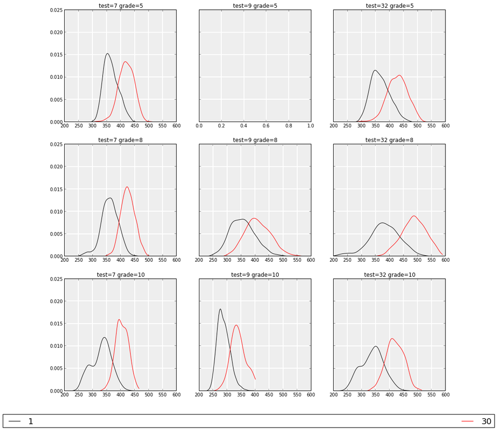

```python
# All students vs gifted

subgroups = [1, 30]
df = get_data(subgroups)
plot_groups_grid(df, subgroups, grades, tests)
```

## Male vs Female

- 3 (Black) Male
- 4 (Red) Female

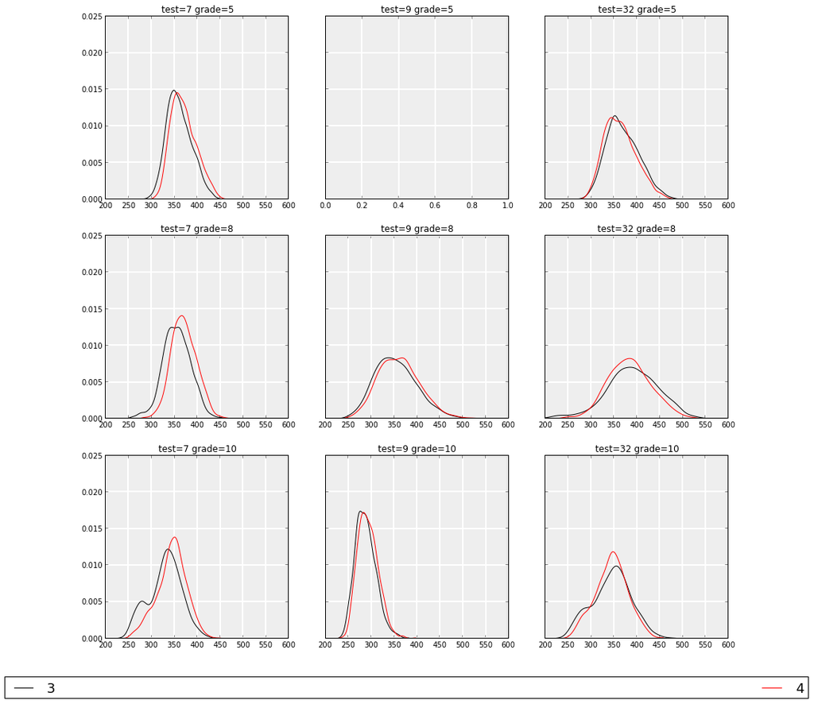

```python
# Male Vs Female
subgroups = [3,4]
df = get_data(subgroups)
plot_groups_grid(df, subgroups, grades, tests)
```

## Economic Status

- 31 (Black) Economically Disadvantaged
- 111 (Red) Not Economically Disadvantaged

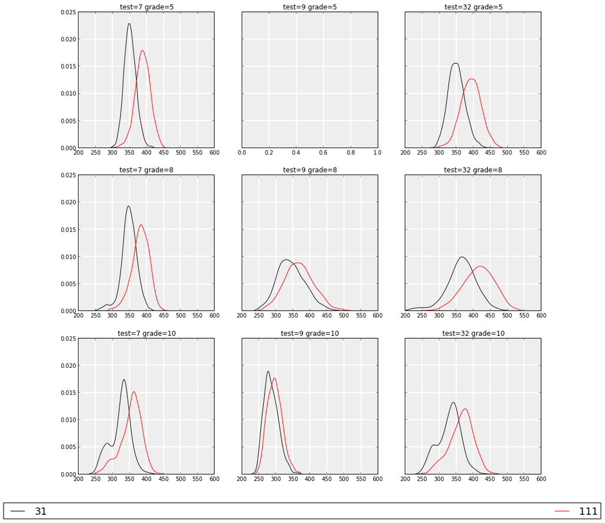

```python
# Economic Status
subgroups = [31,111]
df = get_data(subgroups)
plot_groups_grid(df, subgroups, grades, tests)
```